# Values Three-Way Interactions

## Egoistic Values

### Ego x Norm

Is the slope of the relationship between egoistic values & consumer intentions stronger in any one of the norm conditions compared to the others?

```r
ego_norm_slopes <- emtrends(mod_mice, pairwise~norm_condition, var = "egoistic_center", adjust = "none")

ego_norm_slopes$emtrends %>%
  knitr::kable(digits = 2)
```

| norm_condition | egoistic_center.trend | SE | df | lower.CL | upper.CL |
| --- | --- | --- | --- | --- | --- |
| control_norm | -0.36 | 0.09 | 1038 | -0.54 | -0.19 |
| descriptive_norm | -0.26 | 0.11 | 1038 | -0.47 | -0.06 |
| convention_norm | -0.36 | 0.09 | 1038 | -0.53 | -0.19 |
| social_norm | -0.26 | 0.09 | 1038 | -0.44 | -0.08 |
| moral_norm | -0.24 | 0.09 | 1038 | -0.42 | -0.05 |

```r
ego_norm_slopes$contrasts %>%
  knitr::kable(digits = c(NA,2,2,2,2,3)) # correct p-values
```

| contrast | estimate | SE | df | t.ratio | p.value |
| --- | --- | --- | --- | --- | --- |
| control_norm - descriptive_norm | -0.10 | 0.14 | 1038 | -0.73 | 0.467 |
| control_norm - convention_norm | 0.00 | 0.12 | 1038 | -0.01 | 0.994 |
| control_norm - social_norm | -0.10 | 0.13 | 1038 | -0.80 | 0.422 |
| control_norm - moral_norm | -0.13 | 0.13 | 1038 | -0.98 | 0.327 |
| descriptive_norm - convention_norm | 0.10 | 0.13 | 1038 | 0.74 | 0.457 |
| descriptive_norm - social_norm | 0.00 | 0.14 | 1038 | -0.01 | 0.995 |
| descriptive_norm - moral_norm | -0.03 | 0.14 | 1038 | -0.19 | 0.850 |
| convention_norm - social_norm | -0.10 | 0.12 | 1038 | -0.82 | 0.414 |
| convention_norm - moral_norm | -0.13 | 0.13 | 1038 | -1.00 | 0.316 |
| social_norm - moral_norm | -0.03 | 0.13 | 1038 | -0.20 | 0.843 |

Confidence interval

```r
confint(ego_norm_slopes$contrasts) %>%
  knitr::kable(digits = 2)
```

| contrast | estimate | SE | df | lower.CL | upper.CL |
| --- | --- | --- | --- | --- | --- |
| control_norm - descriptive_norm | -0.10 | 0.14 | 1038 | -0.37 | 0.17 |
| control_norm - convention_norm | 0.00 | 0.12 | 1038 | -0.24 | 0.24 |
| control_norm - social_norm | -0.10 | 0.13 | 1038 | -0.35 | 0.15 |
| control_norm - moral_norm | -0.13 | 0.13 | 1038 | -0.38 | 0.13 |
| descriptive_norm - convention_norm | 0.10 | 0.13 | 1038 | -0.16 | 0.36 |
| descriptive_norm - social_norm | 0.00 | 0.14 | 1038 | -0.27 | 0.27 |
| descriptive_norm - moral_norm | -0.03 | 0.14 | 1038 | -0.30 | 0.25 |
| convention_norm - social_norm | -0.10 | 0.12 | 1038 | -0.34 | 0.14 |
| convention_norm - moral_norm | -0.13 | 0.13 | 1038 | -0.37 | 0.12 |
| social_norm - moral_norm | -0.03 | 0.13 | 1038 | -0.28 | 0.23 |

```r
# On a single graph
describe(average_df$egoistic_center)
```

```
##    vars    n mean   sd median trimmed  mad  min max range skew kurtosis   se
## X1    1 1133    0 0.92      0    0.03 0.89 -3.4   2   5.4 -0.4     0.31 0.03
```

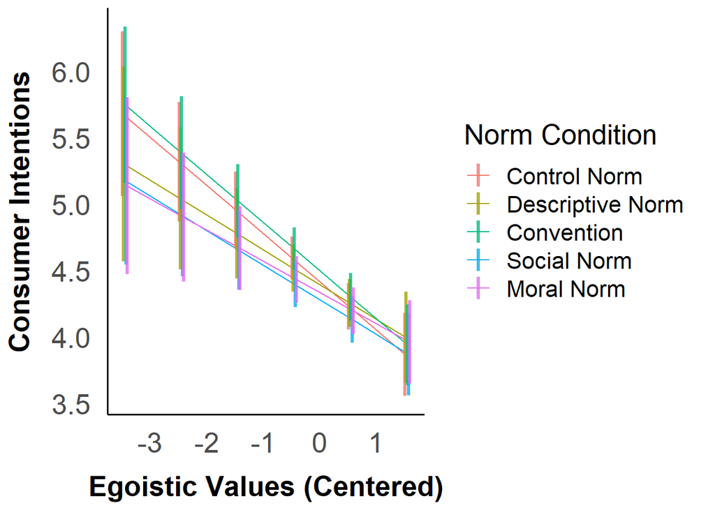

```r
at_list <- list(egoistic_center = seq(-3.45, 2.05, by = 1))

# without data overlaid
emmip(mod_mice, norm_condition ~ egoistic_center, at = at_list, CIs = TRUE, CIarg = list(lwd = 1.2, alpha = 0.8), xlab = "Egoistic Values (Centered)", ylab = "Consumer Intentions") + scale_colour_discrete(name = "Norm Condition", breaks=c("control_norm","descriptive_norm", "convention_norm", "social_norm", "moral_norm"), labels=c("Control Norm", "Descriptive Norm", "Convention", "Social Norm", "Moral Norm")) +theme_apa() + text_settings
```

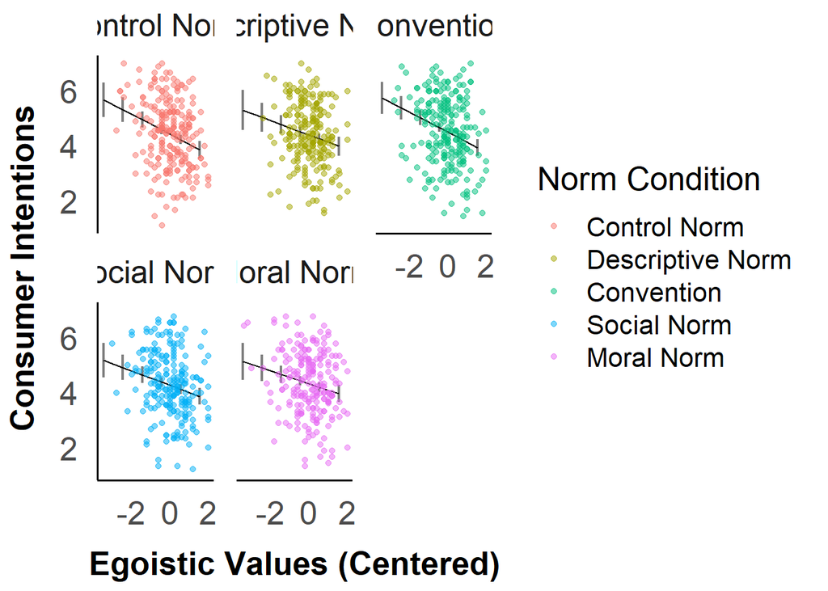

```r
# with data overlaid
emmip(mod_mice, ~ egoistic_center | norm_condition, at = at_list, CIs = TRUE, CIarg = list(lwd = 0.8, alpha = 0.5), xlab = "Egoistic Values (Centered)", ylab = "Consumer Intentions") + scale_colour_discrete(name = "Norm Condition", breaks=c("control_norm","descriptive_norm", "convention_norm", "social_norm", "moral_norm"), labels=c("Control Norm", "Descriptive Norm", "Convention", "Social Norm", "Moral Norm")) + geom_point(data = average_df, aes(x = egoistic_center, y = consumer_intentions, color = norm_condition), alpha = 0.5) + facet_wrap(~norm_condition, labeller = labeller(norm_condition = norm_labs)) +theme_apa() + text_settings
```

### Ego x Framing

Is the slope of the relationship between egoistic values & consumer intentions stronger in any one of the framing conditions compared to the others?

```r
ego_frame_trends <- emtrends(mod_mice, pairwise~framing_condition, var = "egoistic_center", adjust = "none")

ego_frame_trends$emtrends %>%
  knitr::kable(digits = 2)
```

| framing_condition | egoistic_center.trend | SE | df | lower.CL | upper.CL |
| --- | --- | --- | --- | --- | --- |
| control_framing | -0.30 | 0.07 | 1038 | -0.44 | -0.15 |
| pro_env_framing | -0.27 | 0.07 | 1038 | -0.40 | -0.13 |
| self_enh_framing | -0.33 | 0.07 | 1038 | -0.47 | -0.18 |

```r
ego_frame_trends$contrasts %>%
  knitr::kable(digits = c(NA,2,2,2,2,3))
```

| contrast | estimate | SE | df | t.ratio | p.value |
| --- | --- | --- | --- | --- | --- |
| control_framing - pro_env_framing | -0.03 | 0.1 | 1038 | -0.30 | 0.763 |
| control_framing - self_enh_framing | 0.03 | 0.1 | 1038 | 0.33 | 0.745 |
| pro_env_framing - self_enh_framing | 0.06 | 0.1 | 1038 | 0.63 | 0.528 |

Confidence interval

```r
confint(ego_frame_trends$contrasts) %>%
  knitr::kable(digits = 2)
```

| contrast | estimate | SE | df | lower.CL | upper.CL |
| --- | --- | --- | --- | --- | --- |
| control_framing - pro_env_framing | -0.03 | 0.1 | 1038 | -0.23 | 0.17 |
| control_framing - self_enh_framing | 0.03 | 0.1 | 1038 | -0.17 | 0.24 |
| pro_env_framing - self_enh_framing | 0.06 | 0.1 | 1038 | -0.13 | 0.26 |

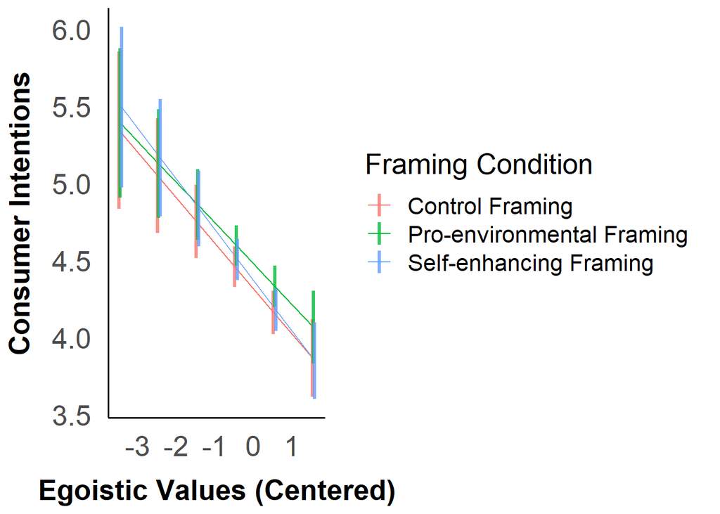

```r
# without data overlaid
emmip(mod_mice, framing_condition ~ egoistic_center, at = at_list, CIs = TRUE, CIarg = list(lwd = 1.2, alpha = 0.8), xlab = "Egoistic Values (Centered)", ylab = "Consumer Intentions") + scale_colour_discrete(name = "Framing Condition", breaks=c("control_framing","pro_env_framing","self_enh_framing"), labels=c("Control Framing", "Pro-environmental Framing", "Self-enhancing Framing")) +theme_apa() + text_settings
```

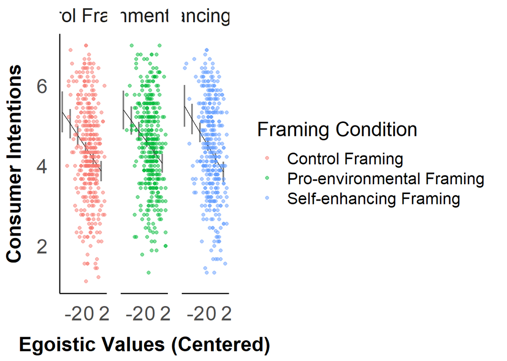

```r
# with data overlaid
emmip(mod_mice, ~ egoistic_center | framing_condition, at = at_list, CIs = TRUE, CIarg = list(lwd = 0.8, alpha = 0.5), xlab = "Egoistic Values (Centered)", ylab = "Consumer Intentions") + scale_colour_discrete(name = "Framing Condition", breaks=c("control_framing","pro_env_framing","self_enh_framing"), labels=c("Control Framing", "Pro-environmental Framing", "Self-enhancing Framing")) + geom_point(data = average_df, aes(x = egoistic_center, y = consumer_intentions, color = framing_condition), alpha = 0.5) + facet_wrap(~framing_condition, labeller = labeller(framing_condition = frame_labs)) +theme_apa() + text_settings
```

### Egoistic x Norm x Framing

```r
ego_frame_norm_trends <- emtrends(mod_mice, pairwise~norm_condition | framing_condition, var = "egoistic_center", adjust = "none")

ego_frame_norm_trends$emtrends %>%
  knitr::kable(digits = 2)
```

| norm_condition | framing_condition | egoistic_center.trend | SE | df | lower.CL | upper.CL |
| --- | --- | --- | --- | --- | --- | --- |
| control_norm | control_framing | -0.24 | 0.15 | 1038 | -0.53 | 0.05 |
| descriptive_norm | control_framing | -0.28 | 0.18 | 1038 | -0.62 | 0.07 |
| convention_norm | control_framing | -0.44 | 0.15 | 1038 | -0.73 | -0.16 |
| social_norm | control_framing | -0.45 | 0.14 | 1038 | -0.73 | -0.17 |
| moral_norm | control_framing | -0.06 | 0.19 | 1038 | -0.44 | 0.31 |
| control_norm | pro_env_framing | -0.52 | 0.14 | 1038 | -0.79 | -0.24 |
| descriptive_norm | pro_env_framing | -0.24 | 0.16 | 1038 | -0.56 | 0.07 |
| convention_norm | pro_env_framing | -0.11 | 0.16 | 1038 | -0.42 | 0.21 |
| social_norm | pro_env_framing | -0.15 | 0.16 | 1038 | -0.46 | 0.16 |
| moral_norm | pro_env_framing | -0.31 | 0.15 | 1038 | -0.60 | -0.02 |
| control_norm | self_enh_framing | -0.33 | 0.17 | 1038 | -0.67 | 0.01 |
| descriptive_norm | self_enh_framing | -0.27 | 0.21 | 1038 | -0.67 | 0.14 |
| convention_norm | self_enh_framing | -0.54 | 0.13 | 1038 | -0.80 | -0.27 |
| social_norm | self_enh_framing | -0.18 | 0.16 | 1038 | -0.50 | 0.14 |
| moral_norm | self_enh_framing | -0.33 | 0.15 | 1038 | -0.62 | -0.05 |

```r
ego_frame_norm_trends$contrasts %>%
  knitr::kable(digits = c(NA,NA,2,2,2,2,3))
```

| contrast | framing_condition | estimate | SE | df | t.ratio | p.value |
| --- | --- | --- | --- | --- | --- | --- |
| control_norm - descriptive_norm | control_framing | 0.03 | 0.23 | 1038 | 0.15 | 0.884 |
| control_norm - convention_norm | control_framing | 0.20 | 0.21 | 1038 | 0.98 | 0.330 |
| control_norm - social_norm | control_framing | 0.21 | 0.21 | 1038 | 1.01 | 0.313 |
| control_norm - moral_norm | control_framing | -0.18 | 0.24 | 1038 | -0.74 | 0.462 |
| descriptive_norm - convention_norm | control_framing | 0.17 | 0.23 | 1038 | 0.74 | 0.460 |
| descriptive_norm - social_norm | control_framing | 0.17 | 0.23 | 1038 | 0.77 | 0.443 |
| descriptive_norm - moral_norm | control_framing | -0.21 | 0.26 | 1038 | -0.82 | 0.415 |
| convention_norm - social_norm | control_framing | 0.01 | 0.20 | 1038 | 0.03 | 0.979 |
| convention_norm - moral_norm | control_framing | -0.38 | 0.24 | 1038 | -1.58 | 0.114 |
| social_norm - moral_norm | control_framing | -0.39 | 0.24 | 1038 | -1.62 | 0.106 |
| control_norm - descriptive_norm | pro_env_framing | -0.27 | 0.21 | 1038 | -1.28 | 0.201 |
| control_norm - convention_norm | pro_env_framing | -0.41 | 0.21 | 1038 | -1.94 | 0.053 |
| control_norm - social_norm | pro_env_framing | -0.36 | 0.21 | 1038 | -1.73 | 0.085 |
| control_norm - moral_norm | pro_env_framing | -0.21 | 0.20 | 1038 | -1.02 | 0.306 |
| descriptive_norm - convention_norm | pro_env_framing | -0.14 | 0.23 | 1038 | -0.61 | 0.539 |
| descriptive_norm - social_norm | pro_env_framing | -0.09 | 0.22 | 1038 | -0.41 | 0.682 |
| descriptive_norm - moral_norm | pro_env_framing | 0.06 | 0.22 | 1038 | 0.29 | 0.771 |
| convention_norm - social_norm | pro_env_framing | 0.05 | 0.22 | 1038 | 0.21 | 0.834 |
| convention_norm - moral_norm | pro_env_framing | 0.20 | 0.22 | 1038 | 0.93 | 0.354 |
| social_norm - moral_norm | pro_env_framing | 0.16 | 0.22 | 1038 | 0.72 | 0.473 |
| control_norm - descriptive_norm | self_enh_framing | -0.06 | 0.27 | 1038 | -0.23 | 0.815 |
| control_norm - convention_norm | self_enh_framing | 0.21 | 0.22 | 1038 | 0.93 | 0.351 |
| control_norm - social_norm | self_enh_framing | -0.15 | 0.24 | 1038 | -0.62 | 0.533 |
| control_norm - moral_norm | self_enh_framing | 0.00 | 0.23 | 1038 | 0.02 | 0.986 |
| descriptive_norm - convention_norm | self_enh_framing | 0.27 | 0.24 | 1038 | 1.11 | 0.267 |
| descriptive_norm - social_norm | self_enh_framing | -0.08 | 0.26 | 1038 | -0.32 | 0.747 |
| descriptive_norm - moral_norm | self_enh_framing | 0.07 | 0.25 | 1038 | 0.27 | 0.784 |
| convention_norm - social_norm | self_enh_framing | -0.35 | 0.21 | 1038 | -1.68 | 0.094 |
| convention_norm - moral_norm | self_enh_framing | -0.20 | 0.19 | 1038 | -1.04 | 0.301 |
| social_norm - moral_norm | self_enh_framing | 0.15 | 0.22 | 1038 | 0.70 | 0.482 |

Confidence interval

```r
confint(ego_frame_norm_trends$contrasts) %>%
  knitr::kable(digits = 2)
```

| contrast | framing_condition | estimate | SE | df | lower.CL | upper.CL |
| --- | --- | --- | --- | --- | --- | --- |
| control_norm - descriptive_norm | control_framing | 0.03 | 0.23 | 1038 | -0.42 | 0.48 |
| control_norm - convention_norm | control_framing | 0.20 | 0.21 | 1038 | -0.20 | 0.61 |
| control_norm - social_norm | control_framing | 0.21 | 0.21 | 1038 | -0.20 | 0.61 |
| control_norm - moral_norm | control_framing | -0.18 | 0.24 | 1038 | -0.65 | 0.30 |
| descriptive_norm - convention_norm | control_framing | 0.17 | 0.23 | 1038 | -0.28 | 0.62 |
| descriptive_norm - social_norm | control_framing | 0.17 | 0.23 | 1038 | -0.27 | 0.62 |
| descriptive_norm - moral_norm | control_framing | -0.21 | 0.26 | 1038 | -0.72 | 0.30 |
| convention_norm - social_norm | control_framing | 0.01 | 0.20 | 1038 | -0.40 | 0.41 |
| convention_norm - moral_norm | control_framing | -0.38 | 0.24 | 1038 | -0.85 | 0.09 |
| social_norm - moral_norm | control_framing | -0.39 | 0.24 | 1038 | -0.85 | 0.08 |
| control_norm - descriptive_norm | pro_env_framing | -0.27 | 0.21 | 1038 | -0.69 | 0.14 |
| control_norm - convention_norm | pro_env_framing | -0.41 | 0.21 | 1038 | -0.83 | 0.01 |
| control_norm - social_norm | pro_env_framing | -0.36 | 0.21 | 1038 | -0.78 | 0.05 |
| control_norm - moral_norm | pro_env_framing | -0.21 | 0.20 | 1038 | -0.61 | 0.19 |
| descriptive_norm - convention_norm | pro_env_framing | -0.14 | 0.23 | 1038 | -0.58 | 0.30 |
| descriptive_norm - social_norm | pro_env_framing | -0.09 | 0.22 | 1038 | -0.53 | 0.35 |
| descriptive_norm - moral_norm | pro_env_framing | 0.06 | 0.22 | 1038 | -0.36 | 0.49 |
| convention_norm - social_norm | pro_env_framing | 0.05 | 0.22 | 1038 | -0.39 | 0.49 |
| convention_norm - moral_norm | pro_env_framing | 0.20 | 0.22 | 1038 | -0.23 | 0.63 |
| social_norm - moral_norm | pro_env_framing | 0.16 | 0.22 | 1038 | -0.27 | 0.58 |
| control_norm - descriptive_norm | self_enh_framing | -0.06 | 0.27 | 1038 | -0.60 | 0.47 |
| control_norm - convention_norm | self_enh_framing | 0.21 | 0.22 | 1038 | -0.23 | 0.64 |
| control_norm - social_norm | self_enh_framing | -0.15 | 0.24 | 1038 | -0.62 | 0.32 |
| control_norm - moral_norm | self_enh_framing | 0.00 | 0.23 | 1038 | -0.44 | 0.45 |
| descriptive_norm - convention_norm | self_enh_framing | 0.27 | 0.24 | 1038 | -0.21 | 0.75 |
| descriptive_norm - social_norm | self_enh_framing | -0.08 | 0.26 | 1038 | -0.60 | 0.43 |
| descriptive_norm - moral_norm | self_enh_framing | 0.07 | 0.25 | 1038 | -0.42 | 0.56 |
| convention_norm - social_norm | self_enh_framing | -0.35 | 0.21 | 1038 | -0.77 | 0.06 |
| convention_norm - moral_norm | self_enh_framing | -0.20 | 0.19 | 1038 | -0.58 | 0.18 |
| social_norm - moral_norm | self_enh_framing | 0.15 | 0.22 | 1038 | -0.27 | 0.58 |

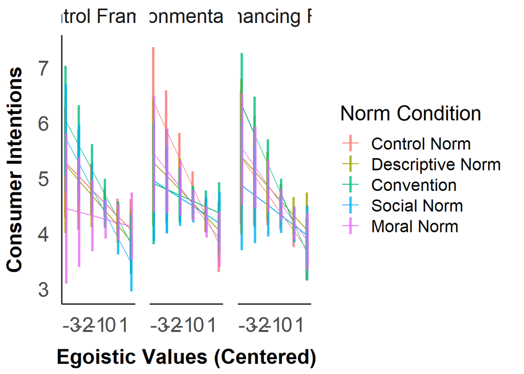

```r
# without data overlaid
emmip(mod_mice, norm_condition ~ egoistic_center | framing_condition, at = at_list, CIs = TRUE, CIarg = list(lwd = 1.2, alpha = 0.8), xlab = "Egoistic Values (Centered)", ylab = "Consumer Intentions") + scale_colour_discrete(name = "Norm Condition", breaks=c("control_norm","descriptive_norm", "convention_norm", "social_norm", "moral_norm"), labels=c("Control Norm", "Descriptive Norm", "Convention", "Social Norm", "Moral Norm")) + facet_wrap(~framing_condition, labeller = labeller(framing_condition = frame_labs)) +theme_apa() + text_settings
```

## Hedonic Values

### Hedonic x Norm

Is the slope of the relationship between hedonic values & consumer intentions stronger in any one of the norm conditions compared to the others?

```r
hed_norm_slopes <- emtrends(mod_mice, pairwise~norm_condition, var = "hedonic_center", adjust = "none")

hed_norm_slopes$emtrends %>%
  knitr::kable(digits = 2)
```

| norm_condition | hedonic_center.trend | SE | df | lower.CL | upper.CL |
| --- | --- | --- | --- | --- | --- |
| control_norm | -0.08 | 0.13 | 1038 | -0.33 | 0.17 |
| descriptive_norm | -0.05 | 0.13 | 1038 | -0.30 | 0.21 |
| convention_norm | 0.12 | 0.11 | 1038 | -0.10 | 0.35 |
| social_norm | -0.18 | 0.12 | 1038 | -0.42 | 0.06 |
| moral_norm | -0.28 | 0.11 | 1038 | -0.49 | -0.06 |

```r
hed_norm_slopes$contrasts %>%
  knitr::kable(digits = c(NA,2,2,2,2,3)) # correct p-values
```

| contrast | estimate | SE | df | t.ratio | p.value |
| --- | --- | --- | --- | --- | --- |
| control_norm - descriptive_norm | -0.04 | 0.18 | 1038 | -0.20 | 0.844 |
| control_norm - convention_norm | -0.21 | 0.17 | 1038 | -1.22 | 0.224 |
| control_norm - social_norm | 0.10 | 0.18 | 1038 | 0.54 | 0.587 |
| control_norm - moral_norm | 0.19 | 0.17 | 1038 | 1.17 | 0.243 |
| descriptive_norm - convention_norm | -0.17 | 0.17 | 1038 | -0.99 | 0.321 |
| descriptive_norm - social_norm | 0.13 | 0.18 | 1038 | 0.73 | 0.463 |
| descriptive_norm - moral_norm | 0.23 | 0.17 | 1038 | 1.35 | 0.176 |
| convention_norm - social_norm | 0.30 | 0.17 | 1038 | 1.81 | 0.070 |
| convention_norm - moral_norm | 0.40 | 0.16 | 1038 | 2.54 | 0.011 |
| social_norm - moral_norm | 0.10 | 0.16 | 1038 | 0.60 | 0.546 |

Confidence interval

```r
confint(hed_norm_slopes$contrasts) %>%
  knitr::kable(digits = 2)
```

| contrast | estimate | SE | df | lower.CL | upper.CL |
| --- | --- | --- | --- | --- | --- |
| control_norm - descriptive_norm | -0.04 | 0.18 | 1038 | -0.39 | 0.32 |
| control_norm - convention_norm | -0.21 | 0.17 | 1038 | -0.54 | 0.13 |
| control_norm - social_norm | 0.10 | 0.18 | 1038 | -0.25 | 0.44 |
| control_norm - moral_norm | 0.19 | 0.17 | 1038 | -0.13 | 0.52 |
| descriptive_norm - convention_norm | -0.17 | 0.17 | 1038 | -0.51 | 0.17 |
| descriptive_norm - social_norm | 0.13 | 0.18 | 1038 | -0.22 | 0.48 |
| descriptive_norm - moral_norm | 0.23 | 0.17 | 1038 | -0.10 | 0.56 |
| convention_norm - social_norm | 0.30 | 0.17 | 1038 | -0.03 | 0.63 |
| convention_norm - moral_norm | 0.40 | 0.16 | 1038 | 0.09 | 0.71 |
| social_norm - moral_norm | 0.10 | 0.16 | 1038 | -0.22 | 0.42 |

```r
# On a single graph
describe(average_df$hedonic_center)
```

```
##    vars    n mean   sd median trimmed  mad   min  max range  skew kurtosis   se
## X1    1 1133    0 0.79   0.28    0.09 0.49 -5.05 0.95     6 -1.45     3.69 0.02
```

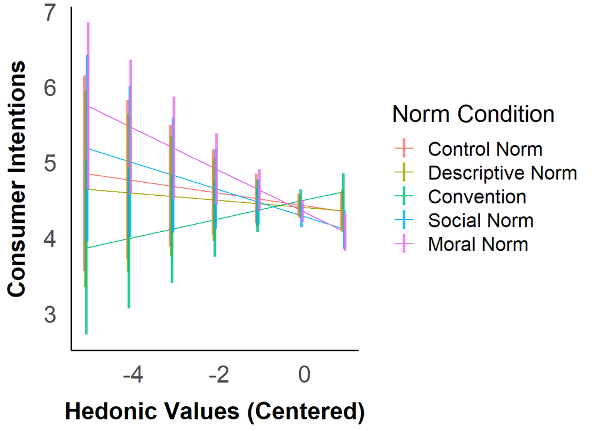

```r
at_list <- list(hedonic_center = seq(-5.1, 1, by = 1))

# without data overlaid
emmip(mod_mice, norm_condition ~ hedonic_center, at = at_list, CIs = TRUE, CIarg = list(lwd = 1.2, alpha = 0.8), xlab = "Hedonic Values (Centered)", ylab = "Consumer Intentions") + scale_colour_discrete(name = "Norm Condition", breaks=c("control_norm","descriptive_norm", "convention_norm", "social_norm", "moral_norm"), labels=c("Control Norm", "Descriptive Norm", "Convention", "Social Norm", "Moral Norm")) +theme_apa() + text_settings
```

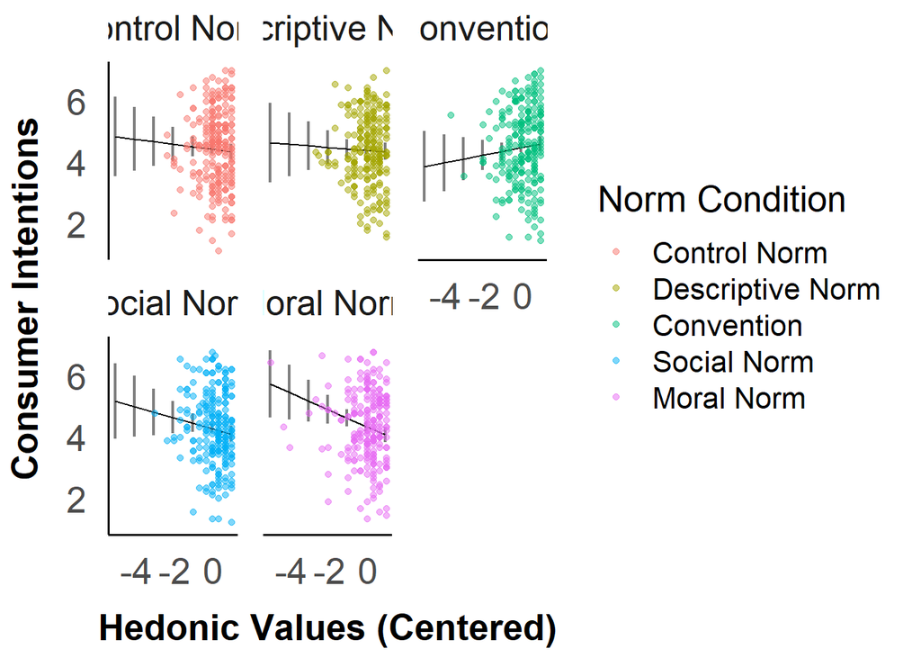

```r
# with data overlaid
emmip(mod_mice, ~ hedonic_center | norm_condition, at = at_list, CIs = TRUE, CIarg = list(lwd = 0.8, alpha = 0.5), xlab = "Hedonic Values (Centered)", ylab = "Consumer Intentions") + scale_colour_discrete(name = "Norm Condition", breaks=c("control_norm","descriptive_norm", "convention_norm", "social_norm", "moral_norm"), labels=c("Control Norm", "Descriptive Norm", "Convention", "Social Norm", "Moral Norm")) + geom_point(data = average_df, aes(x = hedonic_center, y = consumer_intentions, color = norm_condition), alpha = 0.5) + facet_wrap(~norm_condition, labeller = labeller(norm_condition = norm_labs)) +theme_apa() + text_settings
```

### Hedonic x Framing

Is the slope of the relationship between hedonic values & consumer intentions stronger in any one of the framing conditions compared to the others?

```r
hed_frame_trends <- emtrends(mod_mice, pairwise~framing_condition, var = "hedonic_center", adjust = "none")

hed_frame_trends$emtrends %>%
  knitr::kable(digits = 2)
```

| framing_condition | hedonic_center.trend | SE | df | lower.CL | upper.CL |
| --- | --- | --- | --- | --- | --- |
| control_framing | -0.15 | 0.09 | 1038 | -0.33 | 0.03 |
| pro_env_framing | 0.01 | 0.09 | 1038 | -0.17 | 0.19 |
| self_enh_framing | -0.14 | 0.10 | 1038 | -0.33 | 0.05 |

```r
hed_frame_trends$contrasts %>%
  knitr::kable(digits = c(NA,2,2,2,2,3))
```

| contrast | estimate | SE | df | t.ratio | p.value |
| --- | --- | --- | --- | --- | --- |
| control_framing - pro_env_framing | -0.16 | 0.13 | 1038 | -1.22 | 0.223 |
| control_framing - self_enh_framing | -0.01 | 0.13 | 1038 | -0.06 | 0.955 |
| pro_env_framing - self_enh_framing | 0.15 | 0.13 | 1038 | 1.12 | 0.264 |

Confidence interval

```r
confint(hed_frame_trends$contrasts) %>%
  knitr::kable(digits = 2)
```

| contrast | estimate | SE | df | lower.CL | upper.CL |
| --- | --- | --- | --- | --- | --- |
| control_framing - pro_env_framing | -0.16 | 0.13 | 1038 | -0.41 | 0.10 |
| control_framing - self_enh_framing | -0.01 | 0.13 | 1038 | -0.27 | 0.26 |
| pro_env_framing - self_enh_framing | 0.15 | 0.13 | 1038 | -0.11 | 0.41 |

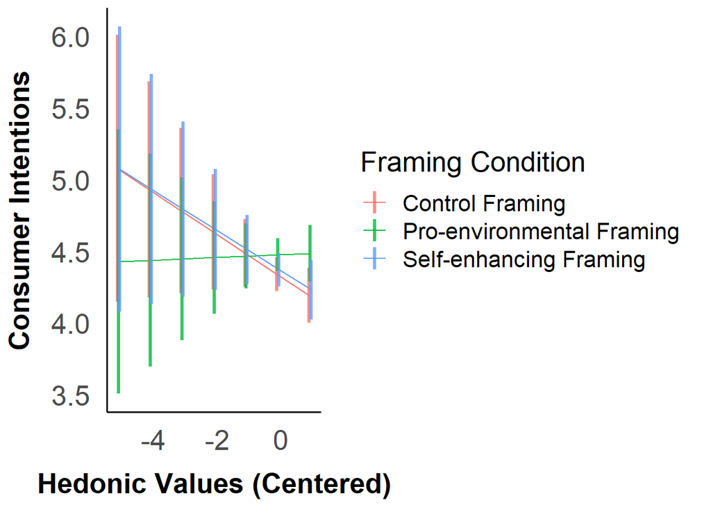

```r
# without data overlaid
emmip(mod_mice, framing_condition ~ hedonic_center, at = at_list, CIs = TRUE, CIarg = list(lwd = 1.2, alpha = 0.8), xlab = "Hedonic Values (Centered)", ylab = "Consumer Intentions") + scale_colour_discrete(name = "Framing Condition", breaks=c("control_framing","pro_env_framing","self_enh_framing"), labels=c("Control Framing", "Pro-environmental Framing", "Self-enhancing Framing")) +theme_apa() + text_settings
```

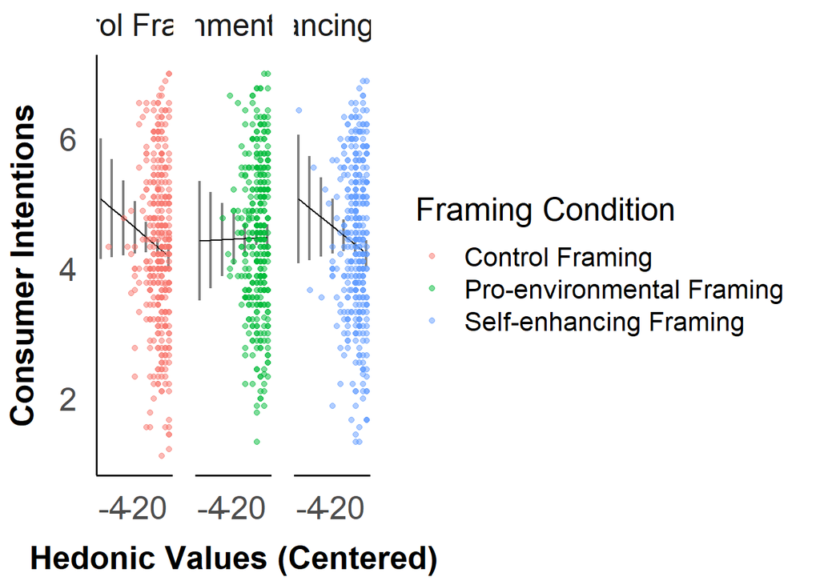

```r
# with data overlaid
emmip(mod_mice, ~ hedonic_center | framing_condition, at = at_list, CIs = TRUE, CIarg = list(lwd = 0.8, alpha = 0.5), xlab = "Hedonic Values (Centered)", ylab = "Consumer Intentions") + scale_colour_discrete(name = "Framing Condition", breaks=c("control_framing","pro_env_framing","self_enh_framing"), labels=c("Control Framing", "Pro-environmental Framing", "Self-enhancing Framing")) + geom_point(data = average_df, aes(x = hedonic_center, y = consumer_intentions, color = framing_condition), alpha = 0.5) + facet_wrap(~framing_condition, labeller = labeller(framing_condition = frame_labs)) +theme_apa() + text_settings
```

### Hedonic x Norm x Framing

```r
hed_frame_norm_trends <- emtrends(mod_mice, pairwise~norm_condition | framing_condition, var = "hedonic_center", adjust = "none")

hed_frame_norm_trends$emtrends %>%
  knitr::kable(digits = 2)
```

| norm_condition | framing_condition | hedonic_center.trend | SE | df | lower.CL | upper.CL |
| --- | --- | --- | --- | --- | --- | --- |
| control_norm | control_framing | -0.34 | 0.18 | 1038 | -0.70 | 0.02 |
| descriptive_norm | control_framing | -0.14 | 0.22 | 1038 | -0.57 | 0.29 |
| convention_norm | control_framing | 0.15 | 0.21 | 1038 | -0.27 | 0.57 |
| social_norm | control_framing | -0.05 | 0.19 | 1038 | -0.42 | 0.32 |
| moral_norm | control_framing | -0.36 | 0.22 | 1038 | -0.79 | 0.06 |
| control_norm | pro_env_framing | 0.15 | 0.21 | 1038 | -0.27 | 0.57 |
| descriptive_norm | pro_env_framing | -0.12 | 0.22 | 1038 | -0.54 | 0.31 |
| convention_norm | pro_env_framing | 0.20 | 0.20 | 1038 | -0.20 | 0.60 |
| social_norm | pro_env_framing | -0.11 | 0.19 | 1038 | -0.49 | 0.27 |
| moral_norm | pro_env_framing | -0.08 | 0.18 | 1038 | -0.44 | 0.28 |
| control_norm | self_enh_framing | -0.06 | 0.25 | 1038 | -0.56 | 0.44 |
| descriptive_norm | self_enh_framing | 0.12 | 0.24 | 1038 | -0.36 | 0.59 |
| convention_norm | self_enh_framing | 0.02 | 0.17 | 1038 | -0.32 | 0.35 |
| social_norm | self_enh_framing | -0.38 | 0.25 | 1038 | -0.87 | 0.10 |
| moral_norm | self_enh_framing | -0.39 | 0.17 | 1038 | -0.72 | -0.06 |

```r
hed_frame_norm_trends$contrasts %>%
  knitr::kable(digits = c(NA,NA,2,2,2,2,3))
```

| contrast | framing_condition | estimate | SE | df | t.ratio | p.value |
| --- | --- | --- | --- | --- | --- | --- |
| control_norm - descriptive_norm | control_framing | -0.19 | 0.28 | 1038 | -0.68 | 0.495 |
| control_norm - convention_norm | control_framing | -0.49 | 0.28 | 1038 | -1.74 | 0.082 |
| control_norm - social_norm | control_framing | -0.29 | 0.26 | 1038 | -1.11 | 0.269 |
| control_norm - moral_norm | control_framing | 0.03 | 0.28 | 1038 | 0.09 | 0.927 |
| descriptive_norm - convention_norm | control_framing | -0.30 | 0.31 | 1038 | -0.97 | 0.335 |
| descriptive_norm - social_norm | control_framing | -0.10 | 0.29 | 1038 | -0.34 | 0.738 |
| descriptive_norm - moral_norm | control_framing | 0.22 | 0.31 | 1038 | 0.72 | 0.473 |
| convention_norm - social_norm | control_framing | 0.20 | 0.29 | 1038 | 0.69 | 0.488 |
| convention_norm - moral_norm | control_framing | 0.52 | 0.30 | 1038 | 1.70 | 0.090 |
| social_norm - moral_norm | control_framing | 0.32 | 0.29 | 1038 | 1.11 | 0.267 |
| control_norm - descriptive_norm | pro_env_framing | 0.26 | 0.31 | 1038 | 0.86 | 0.390 |
| control_norm - convention_norm | pro_env_framing | -0.06 | 0.30 | 1038 | -0.19 | 0.851 |
| control_norm - social_norm | pro_env_framing | 0.25 | 0.29 | 1038 | 0.88 | 0.380 |
| control_norm - moral_norm | pro_env_framing | 0.23 | 0.28 | 1038 | 0.81 | 0.416 |
| descriptive_norm - convention_norm | pro_env_framing | -0.32 | 0.30 | 1038 | -1.07 | 0.286 |
| descriptive_norm - social_norm | pro_env_framing | -0.01 | 0.29 | 1038 | -0.03 | 0.976 |
| descriptive_norm - moral_norm | pro_env_framing | -0.03 | 0.28 | 1038 | -0.12 | 0.906 |
| convention_norm - social_norm | pro_env_framing | 0.31 | 0.28 | 1038 | 1.10 | 0.271 |
| convention_norm - moral_norm | pro_env_framing | 0.28 | 0.27 | 1038 | 1.04 | 0.298 |
| social_norm - moral_norm | pro_env_framing | -0.02 | 0.27 | 1038 | -0.09 | 0.925 |
| control_norm - descriptive_norm | self_enh_framing | -0.18 | 0.35 | 1038 | -0.50 | 0.617 |
| control_norm - convention_norm | self_enh_framing | -0.08 | 0.31 | 1038 | -0.25 | 0.804 |
| control_norm - social_norm | self_enh_framing | 0.32 | 0.35 | 1038 | 0.92 | 0.360 |
| control_norm - moral_norm | self_enh_framing | 0.33 | 0.30 | 1038 | 1.09 | 0.276 |
| descriptive_norm - convention_norm | self_enh_framing | 0.10 | 0.29 | 1038 | 0.34 | 0.736 |
| descriptive_norm - social_norm | self_enh_framing | 0.50 | 0.35 | 1038 | 1.45 | 0.148 |
| descriptive_norm - moral_norm | self_enh_framing | 0.50 | 0.29 | 1038 | 1.72 | 0.085 |
| convention_norm - social_norm | self_enh_framing | 0.40 | 0.30 | 1038 | 1.34 | 0.182 |
| convention_norm - moral_norm | self_enh_framing | 0.41 | 0.24 | 1038 | 1.69 | 0.092 |
| social_norm - moral_norm | self_enh_framing | 0.00 | 0.30 | 1038 | 0.02 | 0.987 |

Confidence interval

```r
confint(hed_frame_norm_trends$contrasts) %>%
  knitr::kable(digits = 2)
```

| contrast | framing_condition | estimate | SE | df | lower.CL | upper.CL |
| --- | --- | --- | --- | --- | --- | --- |
| control_norm - descriptive_norm | control_framing | -0.19 | 0.28 | 1038 | -0.75 | 0.36 |
| control_norm - convention_norm | control_framing | -0.49 | 0.28 | 1038 | -1.04 | 0.06 |
| control_norm - social_norm | control_framing | -0.29 | 0.26 | 1038 | -0.81 | 0.23 |
| control_norm - moral_norm | control_framing | 0.03 | 0.28 | 1038 | -0.53 | 0.58 |
| descriptive_norm - convention_norm | control_framing | -0.30 | 0.31 | 1038 | -0.90 | 0.30 |
| descriptive_norm - social_norm | control_framing | -0.10 | 0.29 | 1038 | -0.66 | 0.47 |
| descriptive_norm - moral_norm | control_framing | 0.22 | 0.31 | 1038 | -0.38 | 0.82 |
| convention_norm - social_norm | control_framing | 0.20 | 0.29 | 1038 | -0.36 | 0.76 |
| convention_norm - moral_norm | control_framing | 0.52 | 0.30 | 1038 | -0.08 | 1.11 |
| social_norm - moral_norm | control_framing | 0.32 | 0.29 | 1038 | -0.24 | 0.88 |
| control_norm - descriptive_norm | pro_env_framing | 0.26 | 0.31 | 1038 | -0.34 | 0.86 |
| control_norm - convention_norm | pro_env_framing | -0.06 | 0.30 | 1038 | -0.63 | 0.52 |
| control_norm - social_norm | pro_env_framing | 0.25 | 0.29 | 1038 | -0.31 | 0.82 |
| control_norm - moral_norm | pro_env_framing | 0.23 | 0.28 | 1038 | -0.32 | 0.78 |
| descriptive_norm - convention_norm | pro_env_framing | -0.32 | 0.30 | 1038 | -0.90 | 0.27 |
| descriptive_norm - social_norm | pro_env_framing | -0.01 | 0.29 | 1038 | -0.58 | 0.56 |
| descriptive_norm - moral_norm | pro_env_framing | -0.03 | 0.28 | 1038 | -0.59 | 0.52 |
| convention_norm - social_norm | pro_env_framing | 0.31 | 0.28 | 1038 | -0.24 | 0.86 |
| convention_norm - moral_norm | pro_env_framing | 0.28 | 0.27 | 1038 | -0.25 | 0.82 |
| social_norm - moral_norm | pro_env_framing | -0.02 | 0.27 | 1038 | -0.55 | 0.50 |
| control_norm - descriptive_norm | self_enh_framing | -0.18 | 0.35 | 1038 | -0.86 | 0.51 |
| control_norm - convention_norm | self_enh_framing | -0.08 | 0.31 | 1038 | -0.68 | 0.53 |
| control_norm - social_norm | self_enh_framing | 0.32 | 0.35 | 1038 | -0.37 | 1.02 |
| control_norm - moral_norm | self_enh_framing | 0.33 | 0.30 | 1038 | -0.26 | 0.92 |
| descriptive_norm - convention_norm | self_enh_framing | 0.10 | 0.29 | 1038 | -0.48 | 0.68 |
| descriptive_norm - social_norm | self_enh_framing | 0.50 | 0.35 | 1038 | -0.18 | 1.18 |
| descriptive_norm - moral_norm | self_enh_framing | 0.50 | 0.29 | 1038 | -0.07 | 1.08 |
| convention_norm - social_norm | self_enh_framing | 0.40 | 0.30 | 1038 | -0.19 | 0.99 |
| convention_norm - moral_norm | self_enh_framing | 0.41 | 0.24 | 1038 | -0.07 | 0.88 |
| social_norm - moral_norm | self_enh_framing | 0.00 | 0.30 | 1038 | -0.58 | 0.59 |

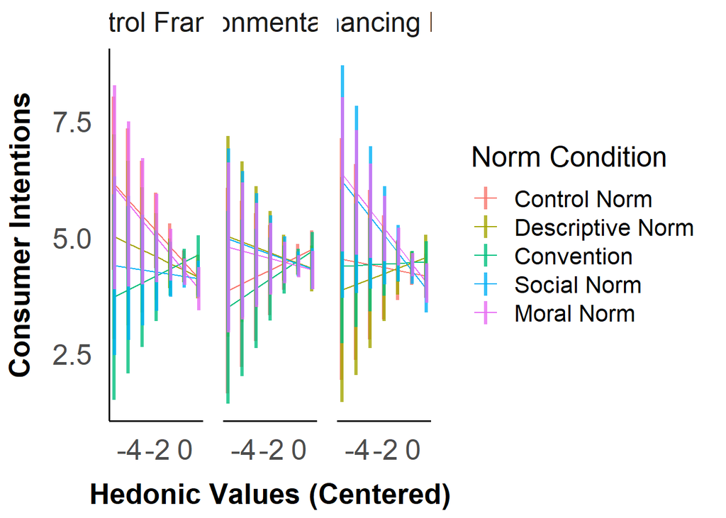

```r
# without data overlaid
emmip(mod_mice, norm_condition ~ hedonic_center | framing_condition, at = at_list, CIs = TRUE, CIarg = list(lwd = 1.2, alpha = 0.8), xlab = "Hedonic Values (Centered)", ylab = "Consumer Intentions") + scale_colour_discrete(name = "Norm Condition", breaks=c("control_norm","descriptive_norm", "convention_norm", "social_norm", "moral_norm"), labels=c("Control Norm", "Descriptive Norm", "Convention", "Social Norm", "Moral Norm")) + facet_wrap(~framing_condition, labeller = labeller(framing_condition = frame_labs)) +theme_apa() + text_settings
```

## Ingroup Identification Interactions

### Ingroup x Norm

Is the slope of the relationship between ingroup identification & consumer intentions stronger in any one of the norm conditions compared to the others?

```r
ing_norm_slopes <- emtrends(mod_mice, pairwise~norm_condition, var = "ingroup_center", adjust = "none")

ing_norm_slopes$emtrends %>%
  knitr::kable(digits = 2)
```

| norm_condition | ingroup_center.trend | SE | df | lower.CL | upper.CL |
| --- | --- | --- | --- | --- | --- |
| control_norm | 0.04 | 0.07 | 1038 | -0.10 | 0.18 |
| descriptive_norm | 0.06 | 0.08 | 1038 | -0.09 | 0.21 |
| convention_norm | 0.02 | 0.08 | 1038 | -0.14 | 0.17 |
| social_norm | 0.05 | 0.08 | 1038 | -0.09 | 0.20 |
| moral_norm | -0.03 | 0.07 | 1038 | -0.17 | 0.11 |

```r
ing_norm_slopes$contrasts %>%
  knitr::kable(digits = c(NA,2,2,2,2,3)) # correct p-values
```

| contrast | estimate | SE | df | t.ratio | p.value |
| --- | --- | --- | --- | --- | --- |
| control_norm - descriptive_norm | -0.01 | 0.11 | 1038 | -0.14 | 0.890 |
| control_norm - convention_norm | 0.03 | 0.11 | 1038 | 0.26 | 0.792 |
| control_norm - social_norm | -0.01 | 0.10 | 1038 | -0.11 | 0.916 |
| control_norm - moral_norm | 0.07 | 0.10 | 1038 | 0.70 | 0.484 |
| descriptive_norm - convention_norm | 0.04 | 0.11 | 1038 | 0.39 | 0.698 |
| descriptive_norm - social_norm | 0.00 | 0.11 | 1038 | 0.03 | 0.974 |
| descriptive_norm - moral_norm | 0.09 | 0.11 | 1038 | 0.81 | 0.416 |
| convention_norm - social_norm | -0.04 | 0.11 | 1038 | -0.36 | 0.719 |
| convention_norm - moral_norm | 0.04 | 0.11 | 1038 | 0.42 | 0.677 |
| social_norm - moral_norm | 0.08 | 0.11 | 1038 | 0.79 | 0.429 |

Confidence interval

```r
confint(ing_norm_slopes$contrasts) %>%
  knitr::kable(digits = 2)
```

| contrast | estimate | SE | df | lower.CL | upper.CL |
| --- | --- | --- | --- | --- | --- |
| control_norm - descriptive_norm | -0.01 | 0.11 | 1038 | -0.22 | 0.19 |
| control_norm - convention_norm | 0.03 | 0.11 | 1038 | -0.18 | 0.23 |
| control_norm - social_norm | -0.01 | 0.10 | 1038 | -0.21 | 0.19 |
| control_norm - moral_norm | 0.07 | 0.10 | 1038 | -0.13 | 0.27 |
| descriptive_norm - convention_norm | 0.04 | 0.11 | 1038 | -0.17 | 0.26 |
| descriptive_norm - social_norm | 0.00 | 0.11 | 1038 | -0.21 | 0.21 |
| descriptive_norm - moral_norm | 0.09 | 0.11 | 1038 | -0.12 | 0.30 |
| convention_norm - social_norm | -0.04 | 0.11 | 1038 | -0.25 | 0.17 |
| convention_norm - moral_norm | 0.04 | 0.11 | 1038 | -0.16 | 0.25 |
| social_norm - moral_norm | 0.08 | 0.11 | 1038 | -0.12 | 0.29 |

```r
# On a single graph
describe(average_df$ingroup_center)
```

```
##    vars    n mean   sd median trimmed  mad   min  max range  skew kurtosis   se
## X1    1 1133    0 1.01   0.01    0.03 0.95 -3.64 2.36     6 -0.27     0.17 0.03
```

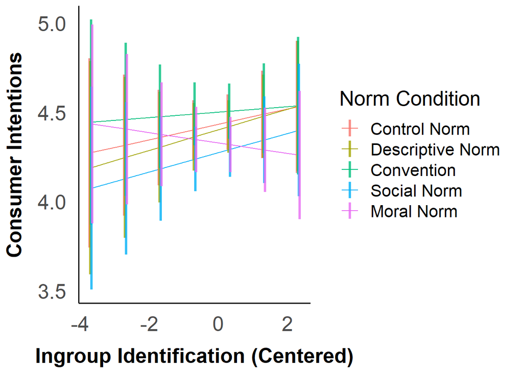

```r
at_list <- list(ingroup_center = seq(-3.69, 2.41, by = 1))

# without data overlaid
emmip(mod_mice, norm_condition ~ ingroup_center, at = at_list, CIs = TRUE, CIarg = list(lwd = 1.2, alpha = 0.8), xlab = "Ingroup Identification (Centered)", ylab = "Consumer Intentions") + scale_colour_discrete(name = "Norm Condition", breaks=c("control_norm","descriptive_norm", "convention_norm", "social_norm", "moral_norm"), labels=c("Control Norm", "Descriptive Norm", "Convention", "Social Norm", "Moral Norm")) +theme_apa() + text_settings
```

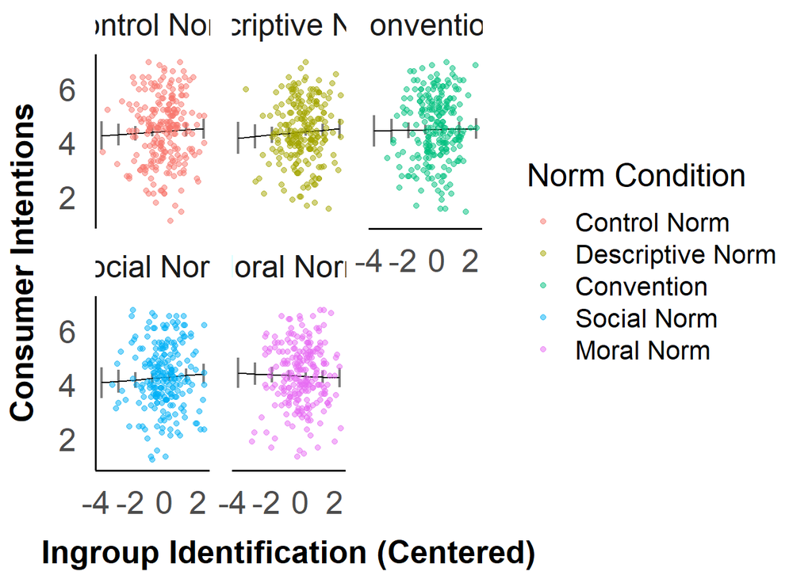

```r
# with data overlaid
emmip(mod_mice, ~ ingroup_center | norm_condition, at = at_list, CIs = TRUE, CIarg = list(lwd = 0.8, alpha = 0.5), xlab = "Ingroup Identification (Centered)", ylab = "Consumer Intentions") + scale_colour_discrete(name = "Norm Condition", breaks=c("control_norm","descriptive_norm", "convention_norm", "social_norm", "moral_norm"), labels=c("Control Norm", "Descriptive Norm", "Convention", "Social Norm", "Moral Norm")) + geom_point(data = average_df, aes(x = ingroup_center, y = consumer_intentions, color = norm_condition), alpha = 0.5) + facet_wrap(~norm_condition, labeller = labeller(norm_condition = norm_labs)) +theme_apa() + text_settings
```

### Ingroup x Framing

Is the slope of the relationship between ingroup identification & consumer intentions stronger in any one of the framing conditions compared to the others?

```r
ing_frame_trends <- emtrends(mod_mice, pairwise~framing_condition, var = "ingroup_center", adjust = "none")

ing_frame_trends$emtrends %>%
  knitr::kable(digits = 2)
```

| framing_condition | ingroup_center.trend | SE | df | lower.CL | upper.CL |
| --- | --- | --- | --- | --- | --- |
| control_framing | 0.04 | 0.06 | 1038 | -0.08 | 0.15 |
| pro_env_framing | -0.01 | 0.06 | 1038 | -0.13 | 0.10 |
| self_enh_framing | 0.06 | 0.06 | 1038 | -0.06 | 0.18 |

```r
ing_frame_trends$contrasts %>%
  knitr::kable(digits = c(NA,2,2,2,2,3))
```

| contrast | estimate | SE | df | t.ratio | p.value |
| --- | --- | --- | --- | --- | --- |
| control_framing - pro_env_framing | 0.05 | 0.08 | 1038 | 0.58 | 0.563 |
| control_framing - self_enh_framing | -0.02 | 0.08 | 1038 | -0.30 | 0.768 |
| pro_env_framing - self_enh_framing | -0.07 | 0.08 | 1038 | -0.86 | 0.392 |

Confidence interval

```r
confint(ing_frame_trends$contrasts) %>%
  knitr::kable(digits = 2)
```

| contrast | estimate | SE | df | lower.CL | upper.CL |
| --- | --- | --- | --- | --- | --- |
| control_framing - pro_env_framing | 0.05 | 0.08 | 1038 | -0.11 | 0.21 |
| control_framing - self_enh_framing | -0.02 | 0.08 | 1038 | -0.19 | 0.14 |
| pro_env_framing - self_enh_framing | -0.07 | 0.08 | 1038 | -0.23 | 0.09 |

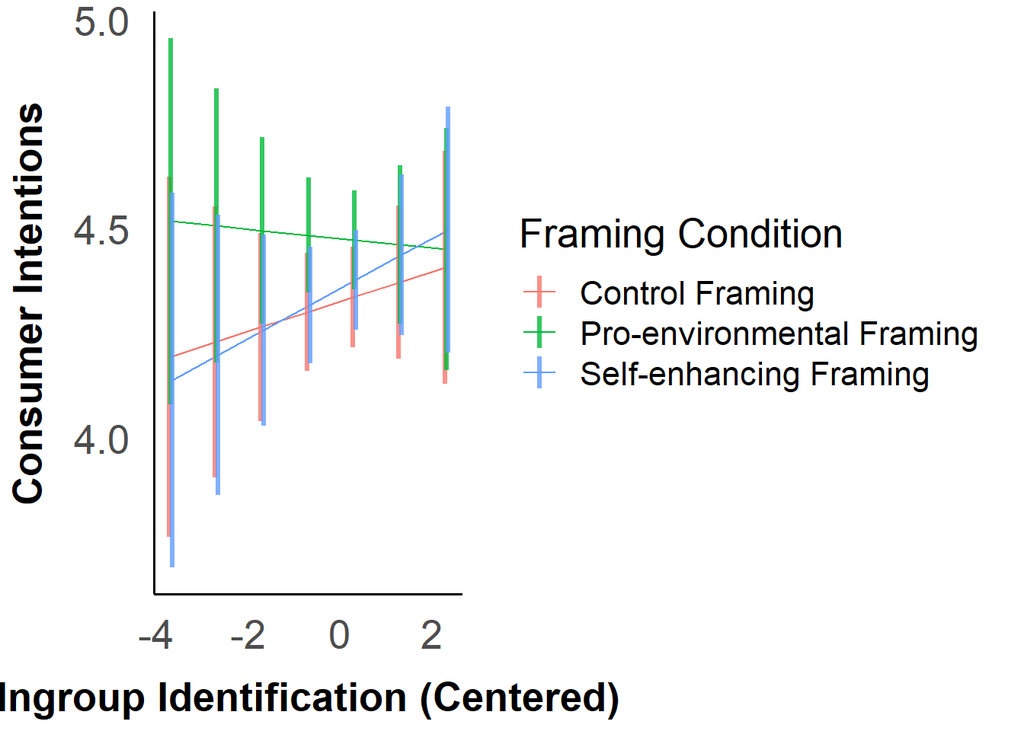

```r
# without data overlaid
emmip(mod_mice, framing_condition ~ ingroup_center, at = at_list, CIs = TRUE, CIarg = list(lwd = 1.2, alpha = 0.8), xlab = "Ingroup Identification (Centered)", ylab = "Consumer Intentions") + scale_colour_discrete(name = "Framing Condition", breaks=c("control_framing","pro_env_framing","self_enh_framing"), labels=c("Control Framing", "Pro-environmental Framing", "Self-enhancing Framing")) +theme_apa() + text_settings
```

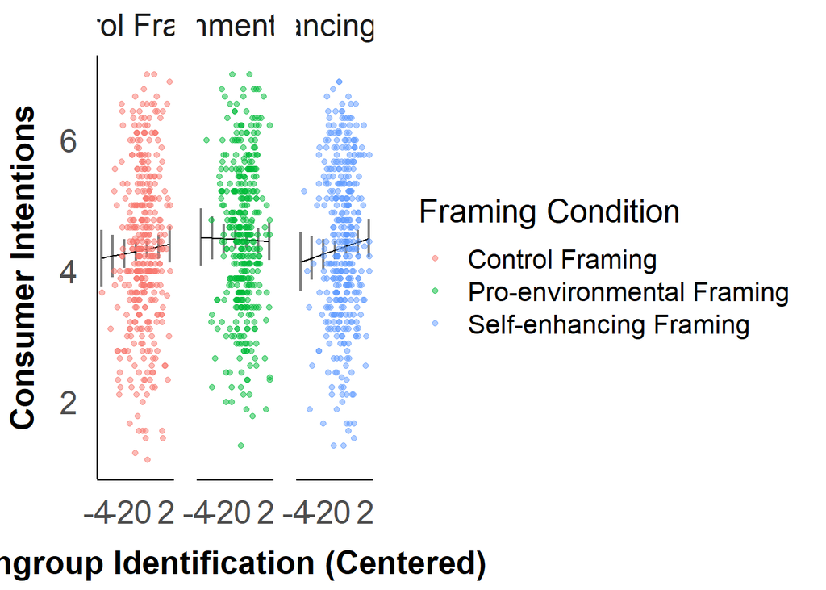

```r
# with data overlaid
emmip(mod_mice, ~ ingroup_center | framing_condition, at = at_list, CIs = TRUE, CIarg = list(lwd = 0.8, alpha = 0.5), xlab = "Ingroup Identification (Centered)", ylab = "Consumer Intentions") + scale_colour_discrete(name = "Framing Condition", breaks=c("control_framing","pro_env_framing","self_enh_framing"), labels=c("Control Framing", "Pro-environmental Framing", "Self-enhancing Framing")) + geom_point(data = average_df, aes(x = ingroup_center, y = consumer_intentions, color = framing_condition), alpha = 0.5) + facet_wrap(~framing_condition, labeller = labeller(framing_condition = frame_labs)) +theme_apa() + text_settings
```

### Ingroup x Norm x Framing

> > Exploratory RQ1: Is there a three-way interaction between ingroup identification, framing, and norm condition?

```r
ing_frame_norm_trends <- emtrends(mod_mice, pairwise~norm_condition | framing_condition, var = "ingroup_center", adjust = "none")

ing_frame_norm_trends$emtrends %>%
  knitr::kable(digits = 2)
```

| norm_condition | framing_condition | ingroup_center.trend | SE | df | lower.CL | upper.CL |
| --- | --- | --- | --- | --- | --- | --- |
| control_norm | control_framing | 0.18 | 0.12 | 1038 | -0.05 | 0.41 |
| descriptive_norm | control_framing | -0.01 | 0.15 | 1038 | -0.31 | 0.28 |
| convention_norm | control_framing | -0.10 | 0.13 | 1038 | -0.36 | 0.16 |
| social_norm | control_framing | 0.01 | 0.11 | 1038 | -0.21 | 0.22 |
| moral_norm | control_framing | 0.10 | 0.12 | 1038 | -0.13 | 0.33 |
| control_norm | pro_env_framing | -0.01 | 0.13 | 1038 | -0.26 | 0.25 |
| descriptive_norm | pro_env_framing | 0.06 | 0.13 | 1038 | -0.20 | 0.31 |
| convention_norm | pro_env_framing | -0.07 | 0.12 | 1038 | -0.32 | 0.17 |
| social_norm | pro_env_framing | -0.07 | 0.13 | 1038 | -0.33 | 0.19 |
| moral_norm | pro_env_framing | 0.04 | 0.13 | 1038 | -0.22 | 0.29 |
| control_norm | self_enh_framing | -0.05 | 0.13 | 1038 | -0.29 | 0.20 |
| descriptive_norm | self_enh_framing | 0.13 | 0.12 | 1038 | -0.10 | 0.36 |
| convention_norm | self_enh_framing | 0.22 | 0.14 | 1038 | -0.07 | 0.50 |
| social_norm | self_enh_framing | 0.23 | 0.15 | 1038 | -0.06 | 0.51 |
| moral_norm | self_enh_framing | -0.23 | 0.13 | 1038 | -0.49 | 0.03 |

```r
ing_frame_norm_trends$contrasts %>%
  knitr::kable(digits = c(NA,NA,2,2,2,2,3))
```

| contrast | framing_condition | estimate | SE | df | t.ratio | p.value |
| --- | --- | --- | --- | --- | --- | --- |
| control_norm - descriptive_norm | control_framing | 0.20 | 0.19 | 1038 | 1.03 | 0.303 |
| control_norm - convention_norm | control_framing | 0.28 | 0.18 | 1038 | 1.59 | 0.112 |
| control_norm - social_norm | control_framing | 0.18 | 0.16 | 1038 | 1.10 | 0.270 |
| control_norm - moral_norm | control_framing | 0.08 | 0.17 | 1038 | 0.48 | 0.631 |
| descriptive_norm - convention_norm | control_framing | 0.08 | 0.20 | 1038 | 0.42 | 0.675 |
| descriptive_norm - social_norm | control_framing | -0.02 | 0.19 | 1038 | -0.10 | 0.919 |
| descriptive_norm - moral_norm | control_framing | -0.12 | 0.19 | 1038 | -0.61 | 0.544 |
| convention_norm - social_norm | control_framing | -0.10 | 0.17 | 1038 | -0.60 | 0.550 |
| convention_norm - moral_norm | control_framing | -0.20 | 0.18 | 1038 | -1.13 | 0.259 |
| social_norm - moral_norm | control_framing | -0.10 | 0.16 | 1038 | -0.60 | 0.546 |
| control_norm - descriptive_norm | pro_env_framing | -0.06 | 0.19 | 1038 | -0.34 | 0.733 |
| control_norm - convention_norm | pro_env_framing | 0.07 | 0.18 | 1038 | 0.38 | 0.704 |
| control_norm - social_norm | pro_env_framing | 0.07 | 0.19 | 1038 | 0.35 | 0.724 |
| control_norm - moral_norm | pro_env_framing | -0.04 | 0.19 | 1038 | -0.23 | 0.820 |
| descriptive_norm - convention_norm | pro_env_framing | 0.13 | 0.18 | 1038 | 0.73 | 0.465 |
| descriptive_norm - social_norm | pro_env_framing | 0.13 | 0.19 | 1038 | 0.70 | 0.486 |
| descriptive_norm - moral_norm | pro_env_framing | 0.02 | 0.18 | 1038 | 0.11 | 0.909 |
| convention_norm - social_norm | pro_env_framing | 0.00 | 0.18 | 1038 | -0.01 | 0.988 |
| convention_norm - moral_norm | pro_env_framing | -0.11 | 0.18 | 1038 | -0.61 | 0.539 |
| social_norm - moral_norm | pro_env_framing | -0.11 | 0.19 | 1038 | -0.58 | 0.562 |
| control_norm - descriptive_norm | self_enh_framing | -0.18 | 0.17 | 1038 | -1.03 | 0.305 |
| control_norm - convention_norm | self_enh_framing | -0.27 | 0.19 | 1038 | -1.39 | 0.164 |
| control_norm - social_norm | self_enh_framing | -0.28 | 0.19 | 1038 | -1.44 | 0.150 |
| control_norm - moral_norm | self_enh_framing | 0.18 | 0.18 | 1038 | 0.99 | 0.324 |
| descriptive_norm - convention_norm | self_enh_framing | -0.09 | 0.19 | 1038 | -0.48 | 0.632 |
| descriptive_norm - social_norm | self_enh_framing | -0.10 | 0.19 | 1038 | -0.53 | 0.595 |
| descriptive_norm - moral_norm | self_enh_framing | 0.36 | 0.18 | 1038 | 2.01 | 0.045 |
| convention_norm - social_norm | self_enh_framing | -0.01 | 0.21 | 1038 | -0.05 | 0.958 |
| convention_norm - moral_norm | self_enh_framing | 0.44 | 0.20 | 1038 | 2.28 | 0.023 |
| social_norm - moral_norm | self_enh_framing | 0.46 | 0.20 | 1038 | 2.31 | 0.021 |

Confidence interval

```r
confint(ing_frame_norm_trends$contrasts) %>%
  knitr::kable(digits = 2)
```

| contrast | framing_condition | estimate | SE | df | lower.CL | upper.CL |
| --- | --- | --- | --- | --- | --- | --- |
| control_norm - descriptive_norm | control_framing | 0.20 | 0.19 | 1038 | -0.18 | 0.57 |
| control_norm - convention_norm | control_framing | 0.28 | 0.18 | 1038 | -0.07 | 0.63 |
| control_norm - social_norm | control_framing | 0.18 | 0.16 | 1038 | -0.14 | 0.49 |
| control_norm - moral_norm | control_framing | 0.08 | 0.17 | 1038 | -0.25 | 0.41 |
| descriptive_norm - convention_norm | control_framing | 0.08 | 0.20 | 1038 | -0.31 | 0.48 |
| descriptive_norm - social_norm | control_framing | -0.02 | 0.19 | 1038 | -0.38 | 0.35 |
| descriptive_norm - moral_norm | control_framing | -0.12 | 0.19 | 1038 | -0.49 | 0.26 |
| convention_norm - social_norm | control_framing | -0.10 | 0.17 | 1038 | -0.44 | 0.23 |
| convention_norm - moral_norm | control_framing | -0.20 | 0.18 | 1038 | -0.55 | 0.15 |
| social_norm - moral_norm | control_framing | -0.10 | 0.16 | 1038 | -0.41 | 0.22 |
| control_norm - descriptive_norm | pro_env_framing | -0.06 | 0.19 | 1038 | -0.43 | 0.30 |
| control_norm - convention_norm | pro_env_framing | 0.07 | 0.18 | 1038 | -0.29 | 0.42 |
| control_norm - social_norm | pro_env_framing | 0.07 | 0.19 | 1038 | -0.30 | 0.43 |
| control_norm - moral_norm | pro_env_framing | -0.04 | 0.19 | 1038 | -0.41 | 0.32 |
| descriptive_norm - convention_norm | pro_env_framing | 0.13 | 0.18 | 1038 | -0.22 | 0.49 |
| descriptive_norm - social_norm | pro_env_framing | 0.13 | 0.19 | 1038 | -0.23 | 0.49 |
| descriptive_norm - moral_norm | pro_env_framing | 0.02 | 0.18 | 1038 | -0.34 | 0.38 |
| convention_norm - social_norm | pro_env_framing | 0.00 | 0.18 | 1038 | -0.36 | 0.36 |
| convention_norm - moral_norm | pro_env_framing | -0.11 | 0.18 | 1038 | -0.47 | 0.24 |
| social_norm - moral_norm | pro_env_framing | -0.11 | 0.19 | 1038 | -0.47 | 0.26 |
| control_norm - descriptive_norm | self_enh_framing | -0.18 | 0.17 | 1038 | -0.51 | 0.16 |
| control_norm - convention_norm | self_enh_framing | -0.27 | 0.19 | 1038 | -0.64 | 0.11 |
| control_norm - social_norm | self_enh_framing | -0.28 | 0.19 | 1038 | -0.65 | 0.10 |
| control_norm - moral_norm | self_enh_framing | 0.18 | 0.18 | 1038 | -0.18 | 0.53 |
| descriptive_norm - convention_norm | self_enh_framing | -0.09 | 0.19 | 1038 | -0.45 | 0.28 |
| descriptive_norm - social_norm | self_enh_framing | -0.10 | 0.19 | 1038 | -0.47 | 0.27 |
| descriptive_norm - moral_norm | self_enh_framing | 0.36 | 0.18 | 1038 | 0.01 | 0.70 |
| convention_norm - social_norm | self_enh_framing | -0.01 | 0.21 | 1038 | -0.41 | 0.39 |
| convention_norm - moral_norm | self_enh_framing | 0.44 | 0.20 | 1038 | 0.06 | 0.83 |
| social_norm - moral_norm | self_enh_framing | 0.46 | 0.20 | 1038 | 0.07 | 0.84 |

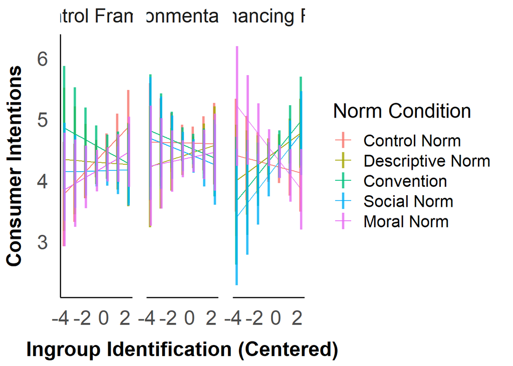

```r
# without data overlaid
emmip(mod_mice, norm_condition ~ ingroup_center | framing_condition, at = at_list, CIs = TRUE, CIarg = list(lwd = 1.2, alpha = 0.8), xlab = "Ingroup Identification (Centered)", ylab = "Consumer Intentions") + scale_colour_discrete(name = "Norm Condition", breaks=c("control_norm","descriptive_norm", "convention_norm", "social_norm", "moral_norm"), labels=c("Control Norm", "Descriptive Norm", "Convention", "Social Norm", "Moral Norm")) + facet_wrap(~framing_condition, labeller = labeller(framing_condition = frame_labs)) +theme_apa() + text_settings
```